# Domaći zadatak 2 — Tri hipoteze

Statistička analiza ukusa, popularnosti i trendova kroz 59.325 parfema

Masa Uzelac RN 40/22

2026-06-10

```r
library(tidyverse)
library(scales)
library(ggridges)
library(patchwork)
library(knitr)
library(kableExtra)
library(ggrepel)
library(rstatix)
```

# 1. Uvod

## Izvor podataka

> **Parfumo** (`parfumo.com`) je najveća svetska zajednica ljubitelja parfema — beleži ocene, note i detalje za 59.325 parfema iz 1.451 parfemske kuće, pokrivajući period od 1709. do 2024. godine. Dataset je preuzet sa Kaggle platforme: [Parfumo Perfume Database — 59k Fragrances](https://www.kaggle.com/datasets/ibrahimqasimi/parfumo-perfume-database-59k-fragrances).

Svaki red predstavlja jedan parfem. Relevantne varijable:

| Varijabla | Tip | Opis |
| --- | --- | --- |
| `Rating_Value` | Numerička | Prosečna ocena zajednice (0–10) |
| `Rating_Count` | Numerička | Broj korisnika koji su ocenili miris |
| `Release_Year` | Numerička | Godina lansiranja; izvor za izvedenu `decade` |
| `Top_Notes` / `Middle_Notes` / `Base_Notes` | Numerička (izvedena) | Broj nota po sloju — prebrojano i kodirano kao `note_count` za H2 vizualizaciju |
| `Main_Accords` | Kategorijska | Dominantni aromatski akordi; izvor za izvedenu `first_accord` |
| `first_accord` | Kategorijska (izvedena) | Dominantni akord (tekst pre prvog zareza); 8 kategorija; korišćena u H1 i H3 |
| `decade` | Kategorijska (izvedena) | Dekada lansiranja iz `Release_Year`; 5 kategorija; korišćena u H3 |
| `Name` / `Brand` | Tekstualna | Korišćeno samo za anotacije na H2 scatter plotu |

## Tri istraživačka pitanja

**Pitanje 1 — ANOVA / Kruskal-Wallis:** > Da li mirisi iz različitih aromatskih kategorija (Floral, Woody, Spicy…) dobijaju statistički različite ocene Parfumo zajednice?

**Pitanje 2 — Korelacija (Spearman):** > Da li popularnost mirisa (broj glasača) korelira sa prosečnom ocenom — i šta nas raspored outlajera otkriva o “kult statusu” u svetu parfema?

**Pitanje 3 — Hi-kvadrat:** > Da li se distribucija dominantnih aromatskih akorda statistički značajno razlikuje između dekada lansiranja (1980-e do 2020-e)?

## Zašto su ova pitanja zanimljiva?

Ocene na Parfumo platformi potiču od ljubitelja mirisa koji svesno ocenjuju i kategorizuju svoja iskustva — što ih čini konzistentnim, ali i pristrasnim prema određenim stilovima.

**Pitanje 1** istražuje da li postoji *aromatski prestiž*: da li zajednica sistematski favorizuje određene stilove (Woody, Spicy) nasuprot masovnim (Fruity, Fresh)?

**Pitanje 2** testira paradoks popularnosti — da li viralni parfemi zaslužuju svoju slavu, ili pravi “hidden gems” sa malo glasova nose najviše ocene?

**Pitanje 3** pita da li su aromatski trendovi koji se pominju u industriji (»oud boom«, »gourmand era«) stvarno statistički merljivi kroz istoriju.

# 2. Priprema podataka

```r
parfumo_raw <- read_csv("~/Downloads/02_Parfumo_Perfumes.csv")
glimpse(parfumo_raw)
```

```
## Rows: 59,325
## Columns: 13
## $ Number        <chr> "455", "0071", "0154", "0162", "0171", "0191", "02", "03…
## $ Name          <chr> "Tabac Écarlate", "Tidal Pool", "Pumpkin Pie", "Wet Ston…
## $ Brand         <chr> "Le Ré Noir", "CB I Hate Perfume", "CB I Hate Perfume", …
## $ Release_Year  <dbl> NA, 2004, 1998, 2006, NA, 1975, NA, NA, NA, NA, NA, NA, …
## $ Concentration <chr> NA, NA, NA, NA, NA, NA, NA, NA, NA, NA, NA, NA, NA, NA, …
## $ Rating_Value  <dbl> NA, NA, NA, NA, NA, NA, NA, NA, NA, NA, NA, NA, NA, 7.8,…
## $ Rating_Count  <dbl> NA, NA, NA, NA, NA, NA, NA, NA, NA, NA, NA, NA, NA, 2, 2…
## $ Main_Accords  <chr> NA, NA, "Green, Leathery, Chypre, Animal", NA, NA, NA, N…
## $ Top_Notes     <chr> NA, "Bergamot", NA, NA, NA, NA, "Coconut", "Basil, Berga…
## $ Middle_Notes  <chr> NA, "French lavender", NA, NA, NA, NA, "Milk, Tonka bean…
## $ Base_Notes    <chr> NA, "Musk, Foulness", NA, NA, NA, NA, "Amber, Musk, Vani…
## $ Perfumers     <chr> "Valery Sokolov / Валерий Соколов", "Harry Frémont", NA,…
## $ URL           <chr> "https://www.parfumo.com/Perfumes/Le_Re_Noir/455-tabac-e…
```

```r
parfumo <- parfumo_raw %>%
  mutate(
    Rating_Value = as.numeric(Rating_Value),
    Rating_Count = as.numeric(Rating_Count),
    Release_Year  = as.numeric(Release_Year),
    # Dominantni akord = prvi u listi (pre prvog zareza)
    first_accord  = str_trim(str_extract(Main_Accords, "^[^,]+")),
    # Kategorijalna varijabla: dekada lansiranja
    decade = case_when(
      Release_Year >= 1980 & Release_Year < 1990 ~ "1980s",
      Release_Year >= 1990 & Release_Year < 2000 ~ "1990s",
      Release_Year >= 2000 & Release_Year < 2010 ~ "2000s",
      Release_Year >= 2010 & Release_Year < 2020 ~ "2010s",
      Release_Year >= 2020 & Release_Year <= 2024 ~ "2020s",
      TRUE ~ NA_character_
    ),
    decade = factor(decade, levels = c("1980s","1990s","2000s","2010s","2020s"))
  )

# Top 8 aromatskih kategorija — definisano ovde da bude dostupno svuda
top_accords <- parfumo %>%
  filter(!is.na(first_accord), !is.na(Rating_Value),
         first_accord != "Synthetic") %>%
  count(first_accord, sort = TRUE) %>%
  slice_head(n = 8) %>%
  pull(first_accord)
```

```r
tibble(
  Varijabla   = c("Rating_Value","Rating_Count","Release_Year","first_accord","decade"),
  Tip         = c("Numerička","Numerička","Numerička","Kategorijska","Kategorijska (izvedena)"),
  Popunjeno   = c(
    sum(!is.na(parfumo$Rating_Value)),
    sum(!is.na(parfumo$Rating_Count)),
    sum(!is.na(parfumo$Release_Year)),
    sum(!is.na(parfumo$first_accord)),
    sum(!is.na(parfumo$decade))
  ),
  `NA vrednosti` = c(
    sum(is.na(parfumo$Rating_Value)),
    sum(is.na(parfumo$Rating_Count)),
    sum(is.na(parfumo$Release_Year)),
    sum(is.na(parfumo$first_accord)),
    sum(is.na(parfumo$decade))
  )
) %>%
  kable(
    caption  = "Pregled ključnih varijabli — broj popunjenih vrednosti i NA",
    format.args = list(big.mark = ".")
  ) %>%
  kable_styling(bootstrap_options = c("striped","hover","condensed"))
```

Pregled ključnih varijabli — broj popunjenih vrednosti i NA

| Varijabla | Tip | Popunjeno | NA vrednosti |
| --- | --- | --- | --- |
| Rating_Value | Numerička | 30.046 | 29.279 |
| Rating_Count | Numerička | 30.046 | 29.279 |
| Release_Year | Numerička | 39.009 | 20.316 |
| first_accord | Kategorijska | 32.225 | 27.100 |
| decade | Kategorijska (izvedena) | 35.933 | 23.392 |

```r
parfumo %>%
  filter(!is.na(Rating_Value), !is.na(Rating_Count)) %>%
  summarise(
    `N parfema`         = n(),
    `Min ocena`         = min(Rating_Value),
    `Medijana ocene`    = median(Rating_Value),
    `Prosek ocene`      = mean(Rating_Value),
    `Max ocena`         = max(Rating_Value),
    `Min glasova`       = min(Rating_Count),
    `Medijana glasova`  = median(Rating_Count),
    `Max glasova`       = max(Rating_Count)
  ) %>%
  kable(digits = 2, caption = "Deskriptivna statistika ocene i broja glasova") %>%
  kable_styling(bootstrap_options = c("striped","hover","condensed"))
```

Deskriptivna statistika ocene i broja glasova

| N parfema | Min ocena | Medijana ocene | Prosek ocene | Max ocena | Min glasova | Medijana glasova | Max glasova |
| --- | --- | --- | --- | --- | --- | --- | --- |
| 30046 | 0 | 7.4 | 7.35 | 10 | 2 | 19 | 2732 |

# 3. Analiza

## 3.1 Pitanje 1: Aromatski prestiž — da li sve kategorije mirisa dobijaju jednake ocene?

```r
parfumo_h1 <- parfumo %>%
  filter(first_accord %in% top_accords, !is.na(Rating_Value)) %>%
  mutate(first_accord = fct_reorder(first_accord, Rating_Value, .fun = median))
```

### Motivaciona vizualizacija

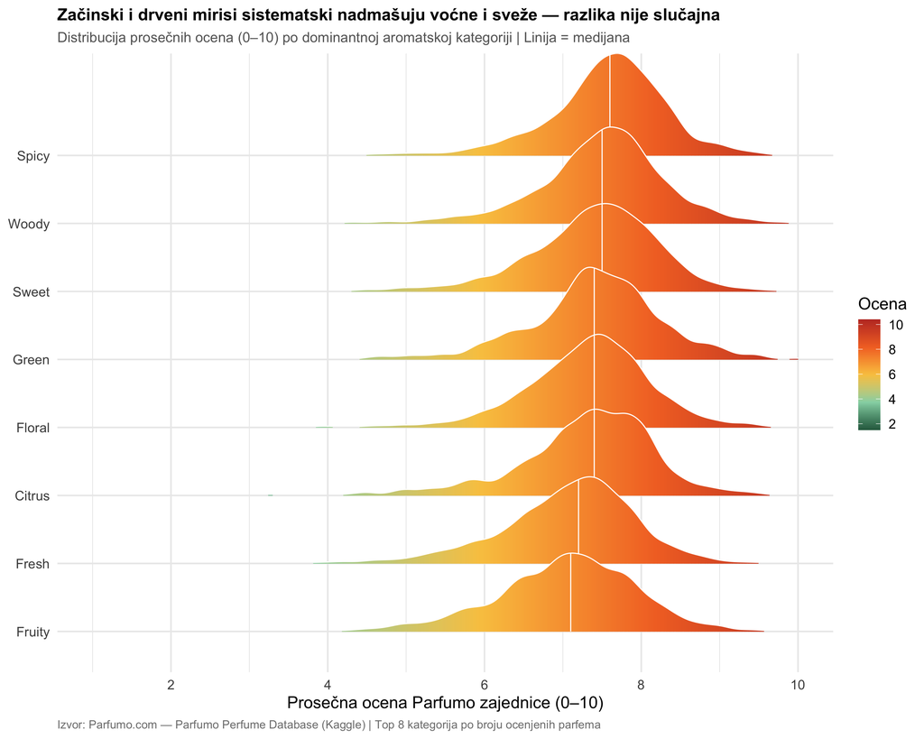

```r
ggplot(parfumo_h1,
       aes(x = Rating_Value, y = first_accord, fill = after_stat(x))) +
  geom_density_ridges_gradient(
    scale          = 1.5,
    quantile_lines = TRUE, quantiles = 2,
    color          = "white", linewidth = 0.4,
    rel_min_height = 0.01
  ) +
  scale_fill_gradientn(
    colors = c("#2d6a4f","#95d5b2","#f9c74f","#f3722c","#c0392b"),
    name   = "Ocena"
  ) +
  scale_x_continuous(limits = c(1, 10), breaks = seq(2, 10, 2)) +
  labs(
    title    = "Začinski i drveni mirisi sistematski nadmašuju voćne i sveže — razlika nije slučajna",
    subtitle = "Distribucija prosečnih ocena (0–10) po dominantnoj aromatskoj kategoriji | Linija = medijana",
    x        = "Prosečna ocena Parfumo zajednice (0–10)",
    y        = NULL,
    caption  = "Izvor: Parfumo.com — Parfumo Perfume Database (Kaggle) | Top 8 kategorija po broju ocenjenih parfema"
  ) +
  theme_minimal(base_size = 13) +
  theme(
    plot.title    = element_text(face = "bold", size = 13, lineheight = 1.2),
    plot.subtitle = element_text(color = "gray40", size = 11),
    plot.caption  = element_text(color = "gray50", size = 9, hjust = 0),
    legend.position = "right"
  )
```

**Komentar:** Odmah se vidi da distribucije nisu identične — Spicy mirisi imaju vidljivo viši pik nego Fruity ili Fresh kategorije. Sve distribucije su asimetrične (nakošene ka nižim ocenama), što već sugeriše da ANOVA nije prikladna.

### Provera pretpostavki

#### Histogrami po kategoriji

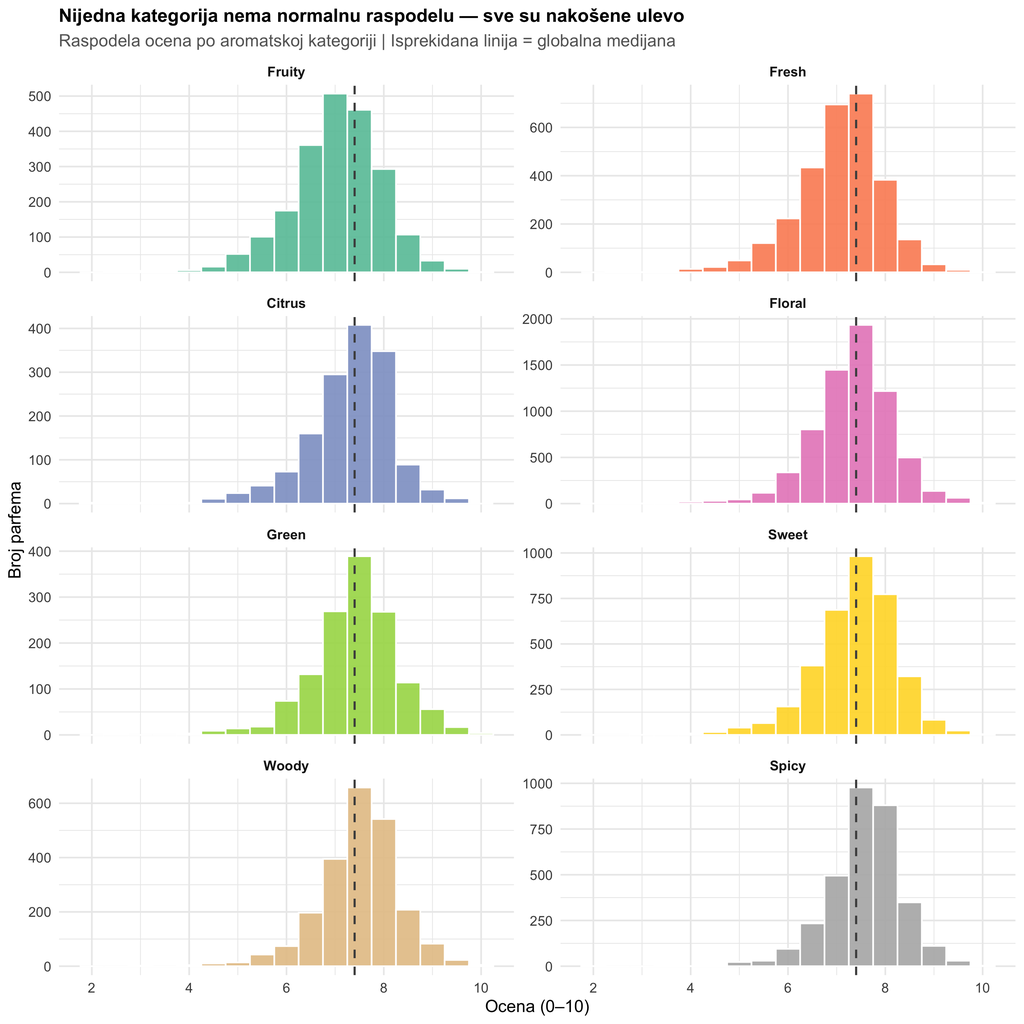

```r
ggplot(parfumo_h1, aes(x = Rating_Value, fill = first_accord)) +
  geom_histogram(binwidth = 0.5, color = "white", alpha = 0.9) +
  geom_vline(xintercept = median(parfumo_h1$Rating_Value),
             linetype = "dashed", color = "gray30", linewidth = 0.7) +
  facet_wrap(~first_accord, ncol = 2, scales = "free_y") +
  scale_fill_brewer(palette = "Set2", guide = "none") +
  scale_x_continuous(breaks = seq(2, 10, 2)) +
  labs(
    title    = "Nijedna kategorija nema normalnu raspodelu — sve su nakošene ulevo",
    subtitle = "Raspodela ocena po aromatskoj kategoriji | Isprekidana linija = globalna medijana",
    x = "Ocena (0–10)", y = "Broj parfema"
  ) +
  theme_minimal(base_size = 12) +
  theme(
    strip.text    = element_text(face = "bold"),
    plot.title    = element_text(face = "bold", size = 13),
    plot.subtitle = element_text(color = "gray40")
  )
```